# Linear Oaxaca-Blinder Decomposition in Argentina 2022

Agustin Talavera

2024-05-08

## 0.1 **Preparación y procesamiento**

```r
# Import data - cargo datos de los 4 trimestres

ephT1_p_22= fread("usu_individual_T122.txt.txt",sep= ";")
ephT2_p_22= fread("usu_individual_T222.txt.txt", sep= ";")
ephT3_p_22= fread("usu_individual_T322.txt.txt", sep= ";")
ephT4_p_22= fread("usu_individual_T422.txt.txt", sep= ";")

## Append data // anexo los 4 trismestres

eph_22= rbind(ephT1_p_22,ephT2_p_22,ephT3_p_22,ephT4_p_22)

colnames(eph_22) <- tolower(colnames(eph_22)) # minus headers//encabezados en minuscula

# geography filter  - elijo Aglomerado gran Resistencia
eph_sem_2<- subset(eph_22, aglomerado==8)

# Age -  filtro para edades
eph_sem_2<- subset(eph_sem_2, ch06>16 & ch06<=30)
#  Inactivos --elimino inactivos
eph_sem_2<- subset(eph_sem_2, estado!=3)
```

```r
# select variables // selecciono variables de interes

eph_224= eph_22[, .(codusu,ch03,aglomerado, estado, ch12, ch13, ch14,
                       pp3f_tot,pp3e_tot,pp03g,p21,
                       tot_p12, pp04a ,ch06, ch04, pp07h, pp07i,
                      ipcf, pondih, p47t, pondii, pp04d_cod, pp04b_cod,
                    trimestre)]
## see the stucture
head(eph_224, 10)
```

```
##                            codusu ch03 aglomerado estado ch12 ch13 ch14
##  1: TQRMNOQXQHLOKQCDEGKDB00777573    2         14      1    6    1   NA
##  2: TQRMNOQXQHLOKQCDEGKDB00777573    3         14      1    6    2    1
##  3: TQRMNOQXQHLOKQCDEGKDB00777573    3         14      3    4    2    2
##  4: TQRMNOSUPHKKPQCDEIJAH00780151    1         33      1    7    1   NA
##  5: TQRMNOSUPHKKPQCDEIJAH00780151    2         33      3    4    1   NA
##  6: TQRMNOSUPHKKPQCDEIJAH00780151    3         33      1    7    1   NA
##  7: TQRMNORUSHKLLNCDEIGED00779493    1         30      1    6    1   NA
##  8: TQRMNORUSHKLLNCDEIGED00779493    2         30      3    4    1   NA
##  9: TQRMNORUSHKLLNCDEIGED00779493    3         30      3    4    1   NA
## 10: TQRMNORUSHKLLNCDEIGED00779493    3         30      3    4    2    1
##     pp3f_tot pp3e_tot pp03g    p21 tot_p12 pp04a ch06 ch04 pp07h pp07i  ipcf
##  1:        0       50     2 150000       0     1   42    2     1     0 77500
##  2:        0       36     2  10000       0     2   19    2     2     2 77500
##  3:       NA       NA    NA      0       0    NA   13    1    NA    NA 77500
```

[output cut: 18 more lines]

```r
# Import index to eliminate inflation effects in salary
# para hallar salario real

ripte= read_excel("ripte_22.xlsx", sheet = 1)

eph_sem_2= left_join(eph_sem_2, ripte, by="trimestre")
```

## 0.2 **Variables creation // Construcción de variables**

EN: Here I follow a few steps in order to create the final dataset.

1. Sub-ocupation: if sb works less than 35 hours per week while wanted more hours.
2. Gender: 1 for man, 0 for woman.
3. Obtain years of education according max level achieved.
4. Obtain a number for job cualifitation level.
5. Dummy for formal or informal job.
6. Dummy for jobs in private or public sector.
7. Classify job depending on the economy sector, turning them into dummies as well.
8. Dummy for full time workers.

Moreover, salaries were not only deflactated in order to eliminate inflation effects but also converted to logarithm, on that way we can interprete the gap as a % difference.

```r
# Construcción de variables

# dummy for subocupation - dummy para subocupado
eph_sem_2[, subocup:=ifelse(pp3e_tot < 35 & pp03g==1, 1, 0)]

# dummy for gender - genero en dummy
eph_sem_2[, hombre:=ifelse(ch04==1, 1, 0)]  #man
eph_sem_2[, mujer:= ifelse(ch04==2, 1, 0)]  #woman

#genero en categoría
eph_sem_2[, genero:=ifelse(ch04==1, "hombre", "mujer")]

# nivel educativo: años educ


eph_sem_2[, año_alcan:= as.numeric(ch14)]

#En este caso se evitarán usar variables categóricas, por lo que educacion se transformó
#en "años_educ" indicando la cantidad de años que tiene cada individuo, al igual que
#calificacion, mostrando del 1(menos calificado) al 4( mas calificado).

# para lograr la variable años de educación
eph_sem_2$años_educ <- NA
eph_sem_2$años_educ[eph_sem_2$ch12 %in% c(1, 2)] <- 0
eph_sem_2$años_educ[eph_sem_2$ch12 == 2 & eph_sem_2$ch13 == 2] <- eph_sem_2$año_alcan[eph_sem_2$ch12 == 2 & eph_sem_2$ch13 == 2]
eph_sem_2$años_educ[eph_sem_2$ch12 == 2 & eph_sem_2$ch13 == 1] <- 6
eph_sem_2$años_educ[eph_sem_2$ch12 == 3 & eph_sem_2$ch13 == 2] <- eph_sem_2$año_alcan[eph_sem_2$ch12 == 3 & eph_sem_2$ch13 == 2]
eph_sem_2$años_educ[eph_sem_2$ch12 == 3 & eph_sem_2$ch13 == 1] <- 9
eph_sem_2$años_educ[eph_sem_2$ch12 == 4 & eph_sem_2$ch13 == 2] <- 6 + eph_sem_2$año_alcan[eph_sem_2$ch12 == 4 & eph_sem_2$ch13 == 2]
eph_sem_2$años_educ[eph_sem_2$ch12 == 4 & eph_sem_2$ch13 == 1] <- 12
eph_sem_2$años_educ[eph_sem_2$ch12 == 5 & eph_sem_2$ch13 == 2] <- 9 + eph_sem_2$año_alcan[eph_sem_2$ch12 == 5 & eph_sem_2$ch13 == 2]
eph_sem_2$años_educ[eph_sem_2$ch12 == 5 & eph_sem_2$ch13 == 1] <- 12
eph_sem_2$años_educ[(eph_sem_2$ch12 %in% c(6, 7)) & eph_sem_2$ch13 == 2] <- 12 + eph_sem_2$año_alcan[(eph_sem_2$ch12 %in% c(6, 7)) & eph_sem_2$ch13 == 2]
eph_sem_2$años_educ[eph_sem_2$ch12 == 7 & eph_sem_2$ch13 == 1] <- 17
eph_sem_2$años_educ[eph_sem_2$ch12 == 6 & eph_sem_2$ch13 == 1] <- 16
eph_sem_2$años_educ[eph_sem_2$ch12 == 8 & eph_sem_2$ch13 == 2] <- 17 + eph_sem_2$año_alcan[eph_sem_2$ch12 == 8 & eph_sem_2$ch13 == 2]
eph_sem_2$años_educ[eph_sem_2$ch12 == 8 & eph_sem_2$ch13 == 1] <- 21

#dataset para verificar si se aplicó bien la transformación
control_educ= eph_sem_2[, .(codusu, ch12, ch13,ch14, año_alcan, años_educ)]


# empleo formal e informal en base a los aportes jubilatorios.
eph_sem_2[, e_formal:= ifelse(pp07h==1, 1, 0 )]

#empleo publico
eph_sem_2[,e_privado:= ifelse(pp04a==2,1,0)]

# tipo  de empleo
## Paso 1: extraigo primeros dos caracteres de la izq del codigo caes
eph_sem_2$caes2 <- ""
eph_sem_2$caes2 <- substr(eph_sem_2$pp04b_cod, 1, 2)
eph_sem_2$caes2[eph_sem_2$caes2 == "Z "] <- ""
eph_sem_2$caes2n <- as.numeric(eph_sem_2$caes2)

# Paso 2: clasifico cada rubro segun los rangos numericos
eph_sem_2[, rubro:= case_when(caes2n>=1 & caes2n<=9 ~ "Sector primario",
                                  caes2n>=10 & caes2n<=33 ~ " Industria",
                                  caes2n==40 ~ "Construccion",
                                  caes2n>=45 & caes2n<=48 ~ "Comercio",
                                  caes2n>=49 & caes2n<=82 | caes2n>=90 &
                                  caes2n<=99  ~ "Servicios",
                                  caes2n>=83 & caes2n<=88 ~ "Sector_publico",
                                  TRUE ~ "Otros")] # los NA pasan a ser "otros".

eph_sem_2[,sector_gral:= case_when(rubro== "Servicios" | rubro=="Comercio" ~
                                "sector_servicios",
                              rubro== "Construccion" | rubro==" Industria" |
                                rubro=="Otros" | rubro=="Sector primario" ~
                                "sector_ciosp",
                              rubro== "Sector_publico" ~ "sector_publico") ]

# Dummys para contemplar sectores
eph_sem_2[, `:=` (dsector_serv= ifelse(sector_gral=="sector_servicios",1,0),
                  dsector_ciosp= ifelse(sector_gral=="sector_ciosp",1,0),
                  dsector_pub= ifelse(sector_gral=="sector_publico",1,0))]




# Calificacion del empleo: del 1 (mas calificado) al 4

eph_sem_2$calif_cod= ""
eph_sem_2$calif_cod= as.numeric(substr(eph_sem_2$pp04d_cod, 5,5))
# categorizando:
eph_sem_2[, calif_tipo:= case_when(calif_cod==1 ~ "Profes",
                                       calif_cod==2 ~ "Tecnic",
                                       calif_cod==3~ "Oper",
                                       calif_cod>3 ~ "NoCalif")]


eph_sem_2[,dummy_calificado:=case_when(calif_tipo=="Profes" | calif_tipo=="Tecnic"~ 1,
                                  calif_tipo=="NoCalif" | calif_tipo=="Oper"~ 0)]

# para crear variable ordinal (del menos calif al mas calif)
eph_sem_2[, calif_orden:= case_when(calif_cod==1 ~ 4,
                                        calif_cod==2 ~ 3,
                                        calif_cod==3~ 2,
                                        calif_cod>3 ~ 1) ]
```

## 0.3 **Salary transformations: Deflating and log**

```r
# salario real
eph_sem_2[,pp3f_tot:=as.numeric(pp3f_tot)]
eph_sem_2[,pp3e_tot:=as.numeric(pp3e_tot)]

eph_sem_2[, Hrs_seman_tot:= pp3e_tot + pp3f_tot]
eph_sem_2<- subset(eph_sem_2, Hrs_seman_tot!=0)

eph_sem_2[, IngLab_sem:=((p21 + tot_p12)/indice)/4] # Deflacto y hallo salario semanal.

eph_sem_2<- subset(eph_sem_2, IngLab_sem>0)

eph_sem_2[, IngLab_hora:=IngLab_sem/Hrs_seman_tot]

eph_sem_2[, ln_IngLab_hora:=log(IngLab_hora)]

# elimino ingresos negativos y demás distorsiones del salario.

eph_sem_2<- subset(eph_sem_2, Hrs_seman_tot!=0)

# contrato full time
eph_sem_2[, full_time:= ifelse(Hrs_seman_tot>=40, 1, 0)]
```

## 0.4 **Filtering the final dataset**

```r
data_final= eph_sem_2[, .(codusu, Log_Ingreso_hora=ln_IngLab_hora,IngLab_hora, hombre, mujer, experiencia=ch06, pondih, pondii ,subocup, empleo_formal= e_formal, años_educ, calif_cod,calif_tipo, calif_empleo=calif_orden, full_time, dummy_calificado, hs_trabajadas_semanal=Hrs_seman_tot, e_privado, sector_gral, rubro, dsector_pub, dsector_serv, dsector_ciosp, genero) ]

#Corrección de NAs
data_final= na.omit(data_final)
```

## 0.5 **Exploración de los datos // EDA process**

This section shows the behavior of the dataset to examine the distribution of the most relevant variables.

**Gráfico 1**. La mayor parte de la muestra posee secundario completo (12 años de educ). **Figure 1.**. Most of the sample has completed high school (12 years of education).

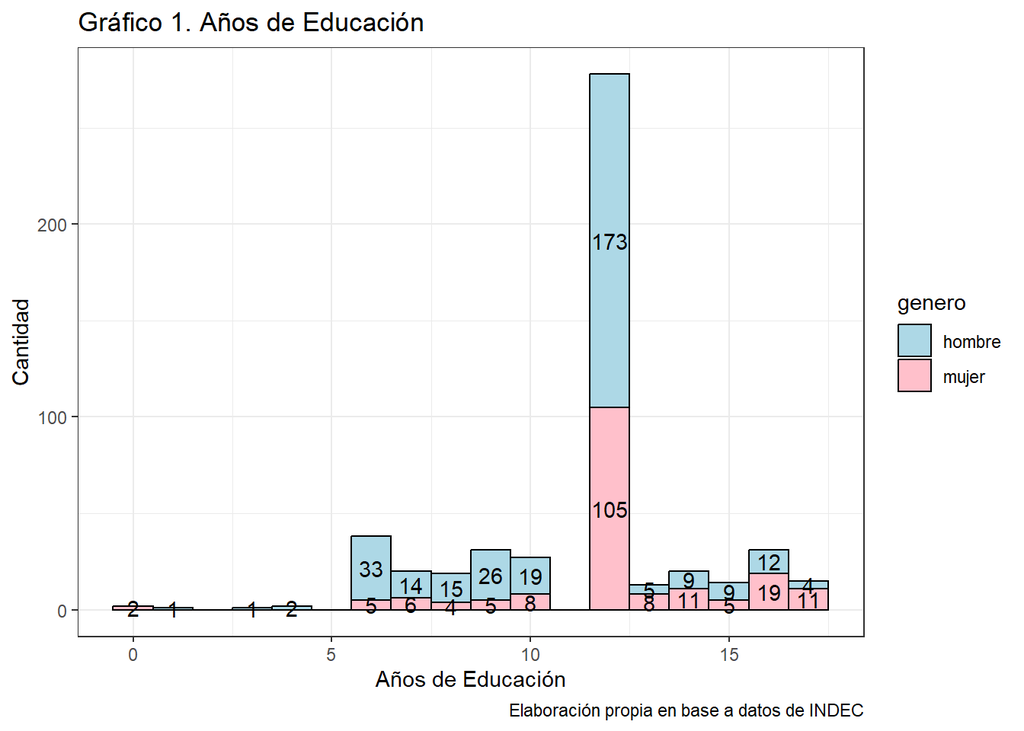

```r
ggplot(data_final, aes(x = años_educ, fill = genero)) +
  geom_histogram(binwidth = 1, color = "black") +
  scale_fill_manual(values = c("lightblue", "pink")) +  # Colores personalizados
  labs(x = "Años de Educación", y = "Cantidad", title = "Gráfico 1. Años de Educación") +
  geom_text(stat = "count", aes(label = after_stat(count)), position = position_stack(vjust = 0.5), color = "black") +
  labs(caption = "Elaboración propia en base a datos de INDEC") + theme_bw()
```

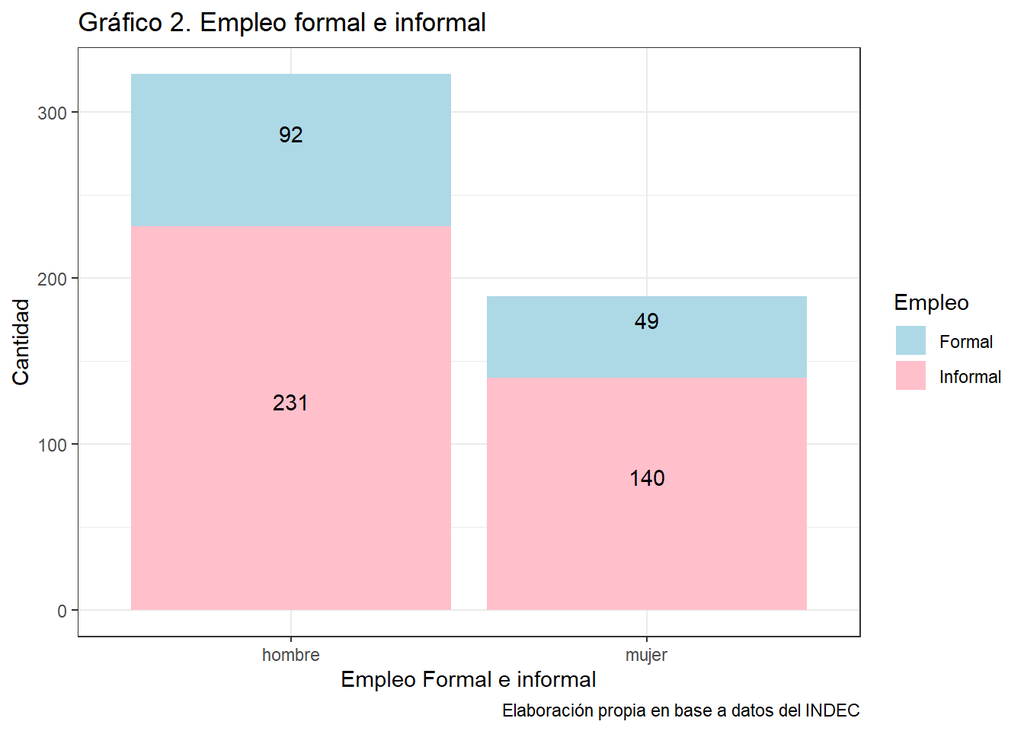

```r
data_final[, Empleo:=ifelse(empleo_formal==1, "Formal", "Informal")]

ggplot(data_final, aes(x = genero, fill = Empleo)) +
    geom_bar(position = "stack", linewidth = 1) +
    scale_fill_manual(values = c("lightblue", "pink")) +  # Cambio de color a lightblue
    labs(x = "Empleo Formal e informal", y = "Cantidad", title = "Gráfico 2. Empleo formal e informal") +  # Cambio de "Frecuencia" a "Cantidad"
    geom_text(stat = "count", aes(label = ..count..), vjust = -0.5, color = "black", position = position_stack(vjust = 0.5)) +
    labs(caption = "Elaboración propia en base a datos del INDEC") +  # Etiqueta en el pie del gráfico
    theme_bw()  # Tema con fondo blanco
```

**Gráfico 3**.  
De todos los contratos full_time, solo el 26% corresponde a mujeres, mientras que de los part-time son 48% los que ocupan las mismas. **Figure 3.**. Of all full-time contracts, only 26% are held by women, whereas 48% of part-time contracts are occupied by women.”

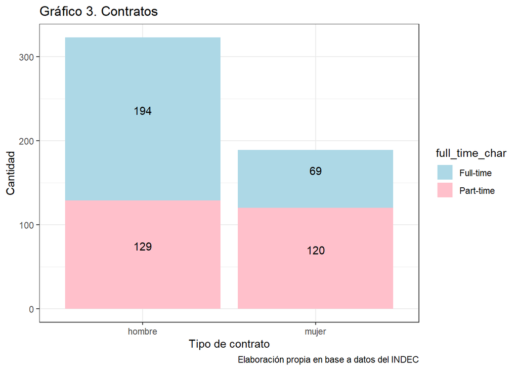

```r
data_final[, full_time_char:= ifelse(full_time==1, "Full-time", "Part-time")]

ggplot(data_final, aes(x = genero, fill = full_time_char)) +
  geom_bar(position = "stack", linewidth = 1) +
  scale_fill_manual(values = c("lightblue", "pink")) +  # Cambio de color a lightblue
  labs(x = "Tipo de contrato", y = "Cantidad", title = "Gráfico 3. Contratos") +  # Cambio de "Frecuencia" a "Cantidad"
  geom_text(stat = "count", aes(label = ..count..), vjust = -0.5, color = "black", position = position_stack(vjust = 0.5)) +
  labs(caption = "Elaboración propia en base a datos del INDEC") +  # Etiqueta en el pie del gráfico
  theme_bw()
```

**Gráfico 4**. Llamativamente, en los segmentos mas capacitados, profesional y técnico, hay muy pocas observaciones (7% del total). **Figure 4.**.Notably, in the most qualified segments (professional and technical), there are just a few observations (7% of the total).

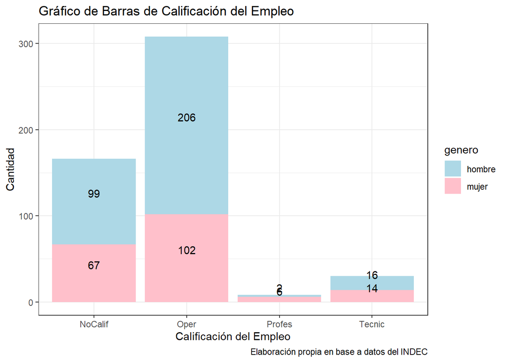

```r
ggplot(data_final, aes(x = calif_tipo, fill = genero)) +
  geom_bar() +
  scale_fill_manual(values = c("lightblue", "pink")) +  # Cambio de color a lightblue para hombres y rosa para mujeres
  labs(x = "Calificación del Empleo", y = "Cantidad", title = "Gráfico de Barras de Calificación del Empleo") +  # Cambio de "Frecuencia" a "Cantidad"
  geom_text(stat = "count", aes(label = ..count..), vjust = -0.5, color = "black", position = position_stack(vjust = 0.5)) +
  labs(caption = "Elaboración propia en base a datos del INDEC") +  # Etiqueta en el pie del gráfico
  theme_bw()  # Tema con fondo blanco
```

**Gráfico 5**. La mayor cantidad de mujeres se concentra en sector público, servicios y comercio. **Figure 5**. The majority of women are concentrated in the public sector, services, and commerce

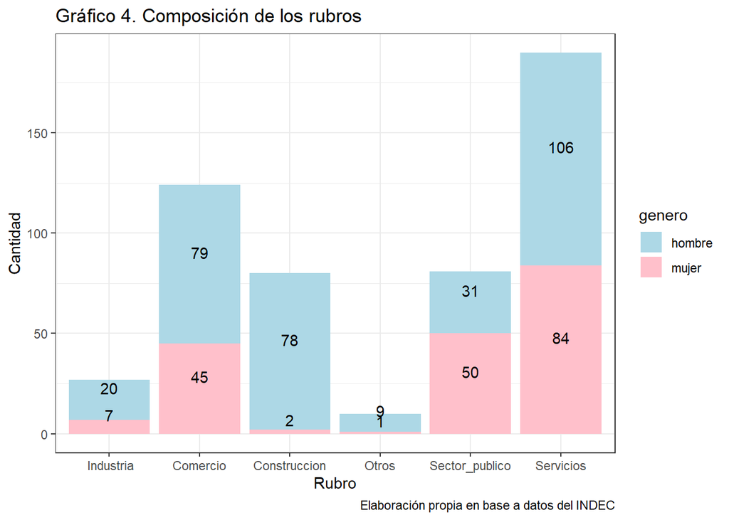

```r
ggplot(data_final, aes(x = rubro, fill = genero)) +
    geom_bar(position = "stack", linewidth = 1) +
    scale_fill_manual(values = c("lightblue", "pink")) +  # Cambio de color a lightblue para hombres y rosa para mujeres
    labs(x = "Rubro", y = "Cantidad", title = "Gráfico 4. Composición de los rubros") +  # Cambio de "Frecuencia" a "Cantidad" y añadido el título
    geom_text(stat = "count", aes(label = ..count..), vjust = -0.5, color = "black", position = position_stack(vjust = 0.5)) +
    labs(caption = "Elaboración propia en base a datos del INDEC") +  # Etiqueta en el pie del gráfico
    theme_bw()  # Tema con fondo blanco
```

## 0.6 **O-A Decomposition**

### 0.6.1 **Código para ejecutar la descomposición**

```r
# descomposicion siendo A= hombres y B= mujeres
resultados <- oaxaca(formula = Log_Ingreso_hora ~ experiencia  + años_educ
                        + hs_trabajadas_semanal + full_time + empleo_formal
                       + dummy_calificado + e_privado+ calif_empleo
                     + subocup  +  dsector_pub + dsector_ciosp
                     | mujer | dsector_pub + dsector_ciosp, # omito sector servicios
                     data = data_final,
                     R = 1000,
                     reg.fun = lm)
```

```r
resultados$n  # tamaño muestral
```

```
## $n.A
## [1] 323
##
## $n.B
## [1] 189
##
## $n.pooled
## [1] 512
```

```r
resultados$y  # dif total porcentual del salario real por hora entre generos.
```

```
## $y.A
## [1] 0.7065024
##
## $y.B
## [1] 0.7483065
##
## $y.diff
## [1] -0.04180408
```

1. In the endowment effect, the contribution to the average difference of the explanatory variables is 11.10% in favor of women.
2. The coefficient effect quantifies the change in women’s wages if they were to be applied the coefficients of men, resulting in 10.93% in favor of men.
3. In the other direction, the joint effects, i.e., considering both the endowment effect and coefficients simultaneously, show a difference of 4% in favor of women, a value that approximates the aggregate gap (4.18%)

1. En el efecto dotación, la contribucion a la diferencia promedio de las variables explicativas, es de 11.10 % a favor de las mujeres.
2. El efecto de los coeficientes cuantifica el cambio en el salario de las mujeres si a estas se le aplican los coeficientes de los hombres. Siendo 10.93% a favor de los hombres.
3. En la otra dirección, los efectos conjuntos, es decir, si se consideran efecto dotación y coeficientes al mismo tiempo, se da que existe una diferencia a favor de las mujeres de 4%, valor que se aproxima a la brecha agregada (4.18%).

```r
resultados$threefold$overall
```

```
##   coef(endowments)     se(endowments) coef(coefficients)   se(coefficients)
##        -0.11107790         0.07676546         0.10931204         0.05202808
##  coef(interaction)    se(interaction)
##        -0.04003821         0.07085612
```

EN: Exploring at a deeper level, regarding the included variables, it can be graphically observed that in the endowment effect, only years of education and hours worked have significant economic relevance, although they exhibit considerable dispersion due to the magnitude of the standard errors for 95% confidence intervals. The economic relevance of weekly working hours has a significant impact in favor of women, which may be due to the fact that the majority of women, nearly 64% to be more specific, are in part-time jobs. As can be seen, most of the differences in endowment are driven by this latter variable

ES: Explorando a un nivel mas profundo, en cuanto a las variables incluidas, se puede apreciar gráficamente que en el efecto dotación (endowment), solo años de educación y horas trabajadas tienen un grado de relevancia económica, aunque poseen mucha dispersión dada la magnitud de los errores estándar para los intervalos de confianza del 95%. La relevancia económica de las horas trabajadas a la semana impacta muy a favor de los mujeres, esto puede deberse a que la mayor parte de las mismas, casi 64% para ser mas específicos, poseen trabajo part-time. Como se puede ver, la mayor parte de las diferencias en la dotación es guiada por esta última variable.

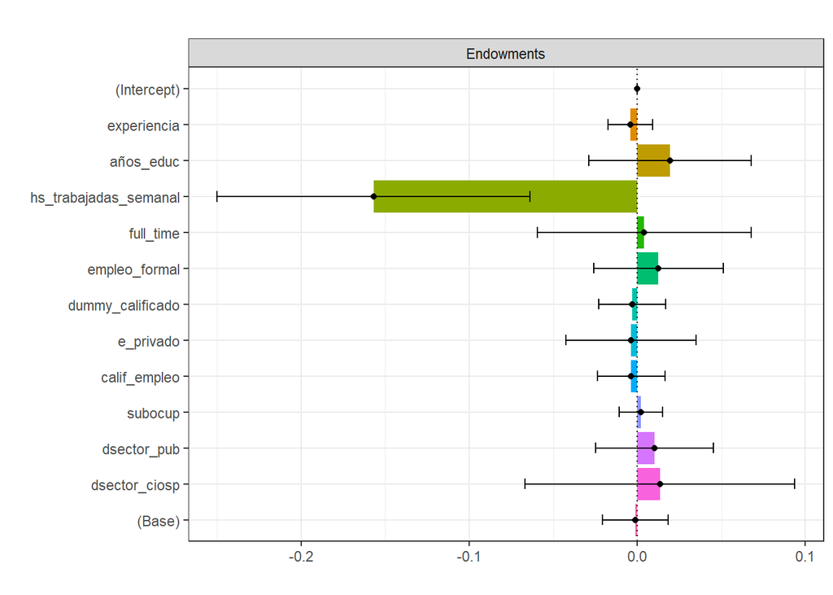

```r
plot(resultados, components = c("endowments"))
```

EN: Regarding the coefficients, there is a significant difference in the intercept in favor of women, but then the factors of years of education, and to a lesser extent, work experience and weekly working hours, more than compensate for this difference

ES: En cuanto a los coeficientes, hay una gran diferencia en el intercepto a favor de las mujeres, pero luego los factores de años de educación, y en menor medida, experiencia laboral y las horas trabajadas a la semana compensan con creces la diferencia.

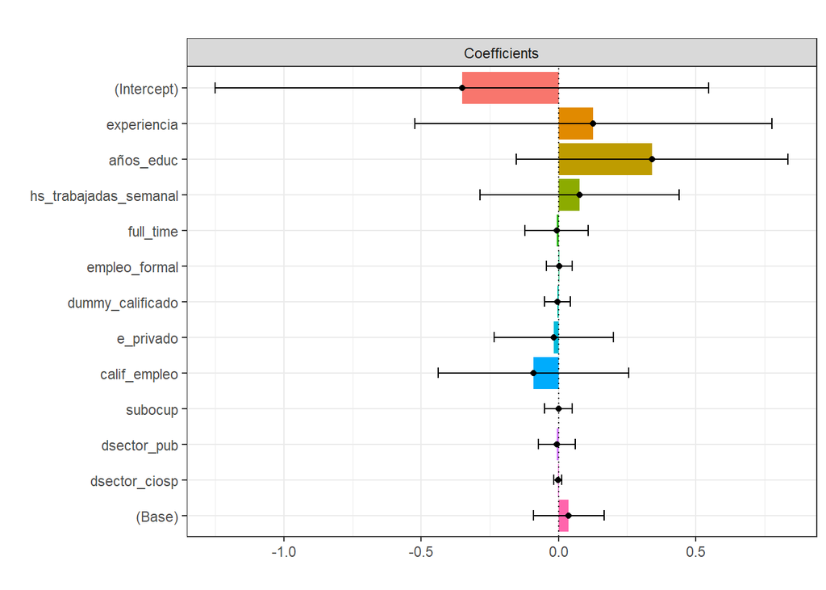

```r
plot(resultados, components = c("coefficients"))
```

EN:

Additionally, if we look at the regressions, for Group B (women), it can be seen that the intercept, formal employment, weekly working hours, and job qualification have statistical and economic significance.

In Group A (men), the intercept, experience, weekly working hours, formal employment, and underemployment all have statistical and economic significance

ES:

Adicionalmente, si miramos las regresiones, para el caso del grupo B (mujeres), se puede ver que el intercepto, el empleo formal, las horas trabajadas y calificación del empleo tienen significancia estadística y económica.

En el grupo A (hombres), gozan de significancia estadistica y económica el intercepto, la experiencia, las horas trabajadas, empleo formal y la subocupación.

```r
 summary(resultados$reg$reg.B)
```

```
##
## Call:
## NULL
##
## Residuals:
##      Min       1Q   Median       3Q      Max
## -1.66415 -0.26815  0.01789  0.31216  1.61950
##
## Coefficients:
##                        Estimate Std. Error t value      Pr(>|t|)
## (Intercept)            1.072618   0.362919   2.956       0.00355 **
## experiencia            0.012143   0.011747   1.034       0.30266
## años_educ             -0.014308   0.015060  -0.950       0.34338
## hs_trabajadas_semanal -0.024312   0.004033  -6.029 0.00000000939 ***
## full_time              0.017497   0.132587   0.132       0.89516
## empleo_formal          0.492802   0.090691   5.434 0.00000018050 ***
## dummy_calificado       0.058810   0.182924   0.321       0.74821
## e_privado             -0.023387   0.112526  -0.208       0.83560
## calif_empleo           0.133886   0.080047   1.673       0.09618 .
## subocup               -0.156085   0.116992  -1.334       0.18387
## dsector_pub           -0.071796   0.121423  -0.591       0.55508
## dsector_ciosp          0.036640   0.165718   0.221       0.82527
## ---
## Signif. codes:  0 '***' 0.001 '**' 0.01 '*' 0.05 '.' 0.1 ' ' 1
##
## Residual standard error: 0.4929 on 177 degrees of freedom
## Multiple R-squared:  0.4472, Adjusted R-squared:  0.4129
## F-statistic: 13.02 on 11 and 177 DF,  p-value: < 0.00000000000000022
```

```r
 summary(resultados$reg$reg.A)
```

```
##
## Call:
## NULL
##
## Residuals:
##      Min       1Q   Median       3Q      Max
## -1.53552 -0.30055  0.01572  0.32635  1.19412
##
## Coefficients:
##                         Estimate Std. Error t value           Pr(>|t|)
## (Intercept)            0.7763540  0.2589090   2.999            0.00293 **
## experiencia            0.0171225  0.0076336   2.243            0.02560 *
## años_educ              0.0136355  0.0099606   1.369            0.17201
## hs_trabajadas_semanal -0.0219135  0.0027619  -7.934 0.0000000000000387 ***
## full_time              0.0004204  0.0833721   0.005            0.99598
## empleo_formal          0.5066417  0.0630261   8.039 0.0000000000000191 ***
## dummy_calificado       0.0191465  0.1361277   0.141            0.88824
## e_privado             -0.0484745  0.0981351  -0.494            0.62169
## calif_empleo           0.0826028  0.0560935   1.473            0.14187
## subocup               -0.1570492  0.0898939  -1.747            0.08162 .
## dsector_pub           -0.1492576  0.1259746  -1.185            0.23699
## dsector_ciosp         -0.0517895  0.0566887  -0.914            0.36165
## ---
## Signif. codes:  0 '***' 0.001 '**' 0.01 '*' 0.05 '.' 0.1 ' ' 1
##
## Residual standard error: 0.441 on 311 degrees of freedom
## Multiple R-squared:  0.4439, Adjusted R-squared:  0.4242
## F-statistic: 22.56 on 11 and 311 DF,  p-value: < 0.00000000000000022
```

**Conclusiones**

EN:

To sum up, there is an aggregate difference of 4.18% in real hourly wages in favor of women, and also in the sample size. The latter is particularly relevant, as only 37% of the sample are women for this segment of the working young population.

The most important variables that can be used to explain the differences are years of education, weekly working hours, work experience, job qualification, and formal employment. Particularly, the variable of weekly working hours has a significant impact on the wage gap in favor of women, although the results should be interpreted with caution due to the fact that the majority of women have part-time jobs, which results in higher hourly wages.

Returns to education and formal employment are higher for men.

However, in the context of this study, it should be considered that there is not enough evidence to assert that the wage gap is truly in favor of women, as the results are statistically insignificant due to the large magnitude of the standard errors.

ES: A nivel general, existe una diferencia agregada de 4.18% en el salario real por hora a favor de las mujeres, y tambien en el tamaño muestral. Este último muy relevante, debido a que solo el 37% de la muestra son mujeres para este segmento de la población joven que trabaja.

Las variables mas importantes que pueden utilizarse para explicar las diferencias son años de educación, horas trabajadas a la semana, experiencia laboral, calificación del empleo y empleo formal. Particularmente la variable de horas trabajadas tiene gran incidencia en la brecha a favor de las mujeres, aunque hay que considerar los resultados con cuidado debido a que la mayoria de las mismas tienen trabajos part-time, haciendo que el salario por hora sea mas alto.

Los retornos a la educación y al empleo formal son mayores en el caso de los hombres.

Por otro lado, en el marco de este estudio, se debe considerar que no hay evidencias suficientes para afirmar de que verdaderamente la brecha salarial esté a favor de las mujeres, dado que los resultados son estadísticamente no significativos debido a la gran magnitud de los errores estandar.